# TF transcriptional waves and pathway analysis

Cong

2024-06-28

# 1 import packages and functions

```r
suppressMessages(library(data.table))
suppressMessages(library(ggplot2))
suppressMessages(library(ggforce))
suppressMessages(library(dplyr))
suppressMessages(library(amap))

suppressMessages(library(clusterProfiler))
suppressMessages(library(org.Mm.eg.db))
suppressMessages(library(enrichplot))
suppressMessages(library(xlsx))
suppressMessages(library(pheatmap))

# load functions
set.seed(42)
fl.sources <- list.files("../../scripts/utils/", full.names = T)
tmp <- sapply(fl.sources,source)
# set plot parameters, which is suitable for CNS publication
plot.format = theme(
    plot.background=element_blank(),
    panel.grid=element_blank(),
    panel.background=element_blank(),
    panel.border=element_rect(color="black", linewidth=0.5, fill=NA),
    axis.line=element_blank(),
    axis.ticks=element_line(color="black",linewidth=0.5),
    axis.text=element_text(color="black", size=7),
    axis.title=element_text(color="black", size=7),
    plot.title=element_text(color="black", size=7),
    legend.background=element_blank(),
    legend.key=element_blank(),
    legend.text=element_text(color="black", size=7),
    legend.title=element_text(color="black", size=7))
```

# 2 import data

We load the PageRank scores matrix along with the meta file containing the cell types.

```r
Data_normed <- read.csv("pagerank.csv", row.names = 1)
group_sorted <- read.table('group_file.txt',header = T, row.names = 1)
group_sorted$oldName <- rownames(group_sorted)
rownames(group_sorted) <- group_sorted$newName
```

# 3 Kmeans clustering of TFs

## 3.1 pca plot

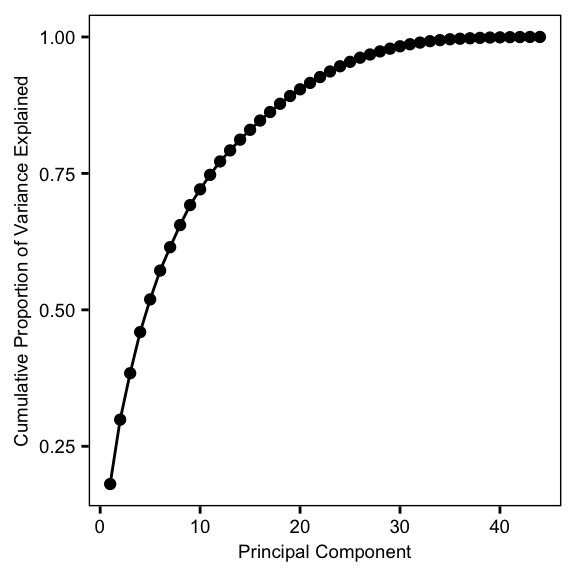

```r
data.pca <- prcomp(Data_normed)

# plot the cumulative variance explained vs # of components
s = (data.pca$sdev)^2/sum((data.pca$sdev)^2)
df2 <- data.frame(x=c(1:length(data.pca$sdev)),y=cumsum(s))
p2 <- ggplot(df2)+aes(x=x,y=y)+geom_point()+geom_line()+
  labs(x="Principal Component",y="Cumulative Proportion of Variance Explained")+
  plot.format
print(p2)
```

```r
## save to file
pdf("pca.pdf", width=3, height=3)
print(p2)
dev.off()
```

## 3.2 hyperparams selection for Kmeans clustering

We need to determine the best distance metric and number of K for Kmeans clustering. To evaluate the clustering quality, we computed the average silhouette width which combines both cohesion (how close data points in a cluster are to each other) and separation (how distinct a cluster is from other clusters). A higher silhouette width value indicates better clustering quality.

Number of k is selected from the range [3, 20]. The lower limit is considering the number of disease states while the upper limit is the balance of searching space and searching speed.

```r
PCNo <- 10
data_reduced <- as.data.frame(prcomp(Data_normed, rank. = PCNo)$x)
df2 <- findOptimal(data_reduced, max_k = 20)
```

```r
# save to file
write.csv(df2, 'kmeans_param.csv')
```

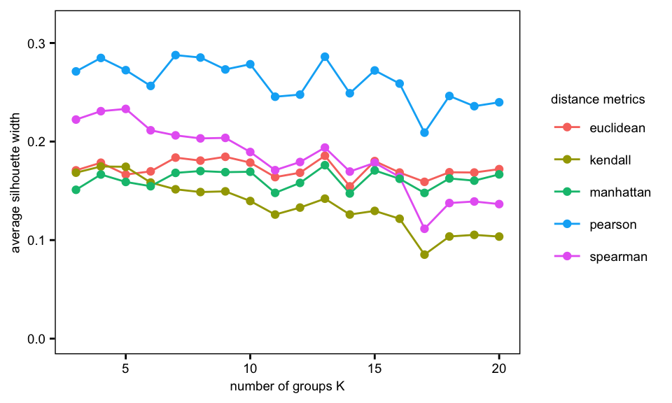

```r
p2 <- ggplot(df2)+aes(x=clusters,y=y,color=method,group=method)+
    geom_line()+geom_point()+xlim(3,20)+
    labs(x='number of groups K',y='average silhouette width',color='distance metrics')+plot.format
print(p2)
```

```r
# save to file
pdf("kmeans_param.pdf",width=3.5,height = 2)
print(p2)
dev.off()
```

## 3.3 Kmeans clustering

```r
set.seed(42)
clusterNo <- 7
Cluster <- amap::Kmeans(data_reduced, centers = clusterNo, nstart = 25,iter.max = 50, method = "pearson")

# extract tfs from same cluster
df2 <- as.data.frame(Cluster$cluster)
names(df2) <- "cluster"
```

```r
# save to file
write.csv(df2, paste0('cluster_k',clusterNo,'.csv'))
```

# 4 generate plots

We now import the pre-defined graph showing the differentiation path.

```r
wavedf <- data.frame(x = c(1,2,2,3,3,4,4,5,5),
                     y = c(3,5,1,3,1,3,0,4,2),
                     samplename = c("Naive","TE","TexProg","MP","TexInt","TRM","TexTerm","TEM","TCM"),
                     labelposx = c(1,2,2,3,3,4,4,5,5),
                     labelposy = c(3,5,1,3,1.4,3,0,4,2)-0.4)
```

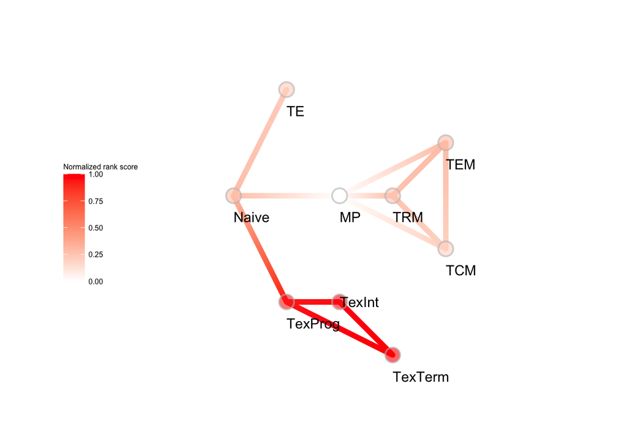

```r
tmp <- lapply(c(1:clusterNo), function(x) outputWave(x, wavedf, df2, Data_normed, group_sorted))
print(tmp[[2]])
```

# 5 pathway analysis

You can skip this part if you already have enriched pathways. Running this part may take ~10 min.

```r
# L <- list.files(path="./", pattern = "c[0-9]+.txt")
# tmp <- lapply(L, gsea)
```

# 6 selected pathways visualization

```r
df <- read.xlsx("SuppFig4 wave GSEA pathways.xlsx", sheetIndex = 1)
df2 <- df %>% dplyr::select(wave.cluster, Description, p.adjust) %>%
      tidyr::pivot_wider(names_from = wave.cluster, values_from = p.adjust) %>% as.data.frame() %>% replace(is.na(.), 1) %>%
      tibble::column_to_rownames("Description")
knitr::kable(df[1:6,1:6], caption = "pathways result") |> kableExtra::kable_styling(latex_options = 'scale_down')
```

pathways result

| wave.cluster | related.cell.state | ID | Description | GeneRatio | BgRatio |
| --- | --- | --- | --- | --- | --- |
| c1 | TE TEM | GO:0007389 | pattern specification process | 71/198 | 480/23355 |
| c1 | TE TEM | GO:0045165 | cell fate commitment | 54/198 | 287/23355 |
| c1 | TE TEM | GO:0098727 | maintenance of cell number | 16/198 | 176/23355 |
| c1 | TE TEM | GO:0007219 | Notch signaling pathway | 15/198 | 180/23355 |
| c1 | TE TEM | GO:0023019 | signal transduction involved in regulation of gene expression | 6/198 | 23/23355 |
| c1 | TE TEM | mmu05202 | Transcriptional misregulation in cancer | 12/58 | 224/9010 |

```r
knitr::kable(df2[1:6,1:6], caption = "data for visualization") |> kableExtra::kable_styling(latex_options = 'scale_down')
```

data for visualization

|  | c1 | c3 | c4 | c5 | c6 | c7 |
| --- | --- | --- | --- | --- | --- | --- |
| pattern specification process | 0e+00 | 1.0000000 | 1.0000000 | 1e+00 | 1.0e+00 | 1.0000000 |
| cell fate commitment | 0e+00 | 0.0003808 | 1.0000000 | 1e+00 | 6.2e-06 | 0.0003793 |
| maintenance of cell number | 0e+00 | 1.0000000 | 1.0000000 | 1e-07 | 1.0e+00 | 1.0000000 |
| Notch signaling pathway | 0e+00 | 1.0000000 | 1.0000000 | 1e+00 | 1.0e+00 | 1.0000000 |
| signal transduction involved in regulation of gene expression | 4e-07 | 1.0000000 | 0.0021083 | 1e+00 | 1.0e+00 | 1.0000000 |
| Transcriptional misregulation in cancer | 5e-07 | 1.0000000 | 1.0000000 | 1e+00 | 1.0e+00 | 1.0000000 |

```r
cutoff <- 0.05
dt2 <- apply(df2,1:2, function(x) min(x, cutoff)) %>% as.data.frame()

## remove the rows with no variation
dt3 <- dt2[rowSums(dt2)!=cutoff*ncol(dt2),]
print(dim(dt3))
```

```
## [1] 49  7
```

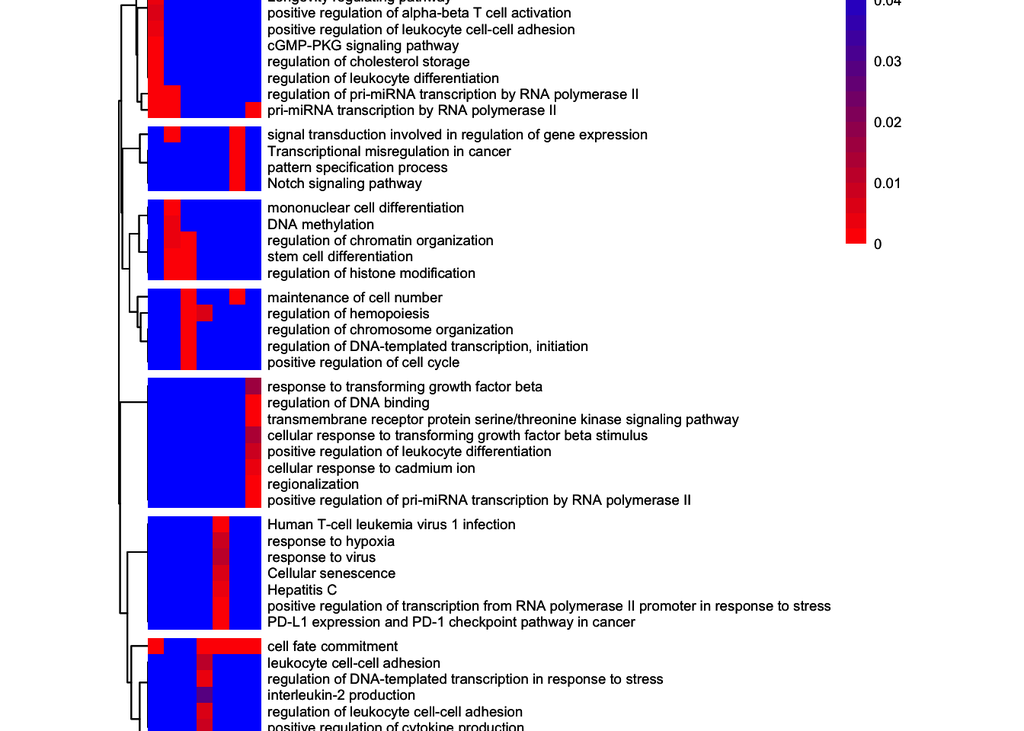

```r
## heatmap
p1 <- pheatmap(dt3, fontsize = 7, show_rownames = T,
                 angle_col = 45, show_colnames = T,
                 cellwidth = 8, cellheight = 8,
                 cluster_rows = T, cluster_cols = T,
                 clustering_distance_rows = "correlation",
                 clustering_distance_cols = "correlation",
                 clustering_method = "average",
                 cutree_rows = 7,
                 treeheight_row = 10, treeheight_col = 10,
                 border_color = NA,
                 color = colorRampPalette(c("red","blue"))(20))
print(p1)
```

```r
## save to file
pdf(paste0("hp_transcriptional_waves_selected_pathway_summary_",cutoff,"_max_hclust_cluster.pdf"))
print(p1)
dev.off()
```